### Polygenic risk scores predict genetic predisposition of complex traits

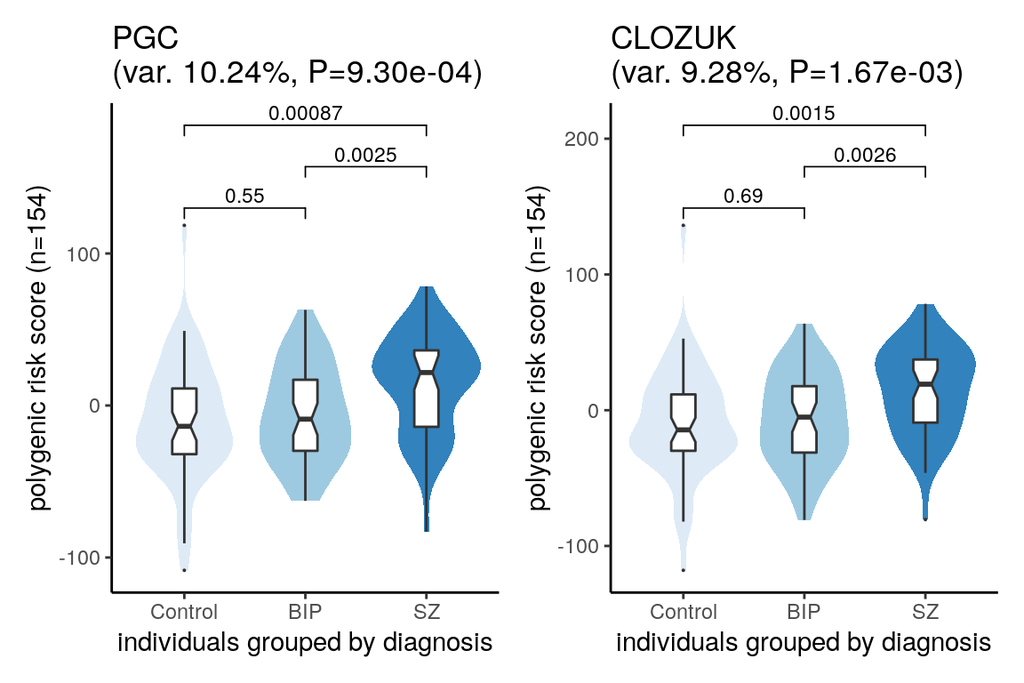

PDF

**Fig.** Unsupervised polygenic risk scores (PRS) constructed by common variants (MAF $\ge$ 5%) predict disease genetic predisposition of Schizophrenia.

We trained PRS models with the two different GWAS summary statistics (PGC only (Schizophrenia Working Group of the Psychiatric Genomics Consortium, 2014) and PGC + CLOZUK meta analysis (Pardiñas et al., 2018)) without using the label of disease diagnosis. In our PRS model, we only need to estimate L2-regularization parameter $\tau$, and each $\tau$ value was selected to maximize consistency of PRS results across multiple reference panels. Here, we optimized for consistency between the results of our cohort and the 1000 genomes project (The 1000 Genomes Project Consortium et al., 2015) cohort with European ancestry (see the methods for details).

### Expression quantitative trait score (eQTS) analysis estimates the association between cell-type-specific gene expression and PRS

```r
################################################################
eqts.file = "share/Ruzicka/eQTS.gz"
dir.create(dirname(eqts.file), recursive=TRUE, showWarnings=FALSE)

if(!file.exists(eqts.file)) {

  a.data = load.data("../data/final_scores.RData")
  PBs = a.data$PBs

  calc.assoc <- function(j, .prs) {

    .mat = PBs[[j]] %>% SummarizedExperiment::assay()
    .ct = names(PBs)[j]
    .prs = .prs %>% select(iid, score)

    log.msg("%d, %s", j, .ct)

    .dt = .mat %>%
      as.data.frame() %>%
      mutate(hgnc_symbol = rownames(.mat)) %>%
      gather(key="batch.hto", value="x", -hgnc_symbol) %>%
      separate("batch.hto", c("Batch", "HTO"), sep="[.]") %>%
      left_join(.hto, by = c("HTO", "Batch")) %>%
      select(-HTO, -Batch) %>%
      left_join(.prs, by = "iid") %>%
      as.data.table

    xx = dcast(.dt, iid ~ hgnc_symbol, value.var = "x")

    yy = tibble(iid = xx$iid) %>%
      left_join(.prs, by = "iid")

    xx = xx %>% select(-iid) %>% as.matrix %>% scale
    yy = yy %>% select(-iid) %>% as.matrix %>% scale

    xx[is.na(xx)] = 0

    ######################
    ## remove top 3 PCs ##
    ######################

    .svd = rsvd::rsvd(xx, k=3)
    .remove = zqtl::calc.qtl.stat(.svd$u, as.matrix(yy)) %>%
      filter(p.val < 1e-2) %>% select(x.col) %>% unlist(use.names=FALSE)

    uu = .svd$u
    if(length(.remove) > 0) {
      uu = uu[, - .remove, drop=FALSE]
    }

    xx.resid = lm(xx ~ uu) %>% residuals %>% as.matrix

    x.tib = tibble(gene = colnames(xx)) %>%
      mutate(x.col = 1:n())

    ret = zqtl::calc.qtl.stat(xx.resid, yy) %>%
      left_join(x.tib, by = "x.col") %>%
      select(-y.col, -x.col) %>%
      mutate(celltype = .ct)

    log.msg("done ... %d, %s", j, .ct)

    return(ret)
  }

  .gwas.files = list.files("share/PRS_Ruzicka/", ".prs.gz", full.names=TRUE)

  calc.assoc.gwas <- function(i) {
    .prs = .gwas.files[i] %>%
      fread() %>%
      as.data.table()

    .gwas = .gwas.files[i] %>% basename() %>% str_remove_all(".prs.gz")

    lapply(1:length(PBs), calc.assoc, .prs = .prs) %>%
      bind_rows() %>%
      mutate(gwas = .gwas) %>%
      as.data.table
  }

  eqts.tab = lapply(1:length(.gwas.files), calc.assoc.gwas) %>%
    bind_rows() %>% as.data.table

  fwrite(eqts.tab, eqts.file)

} else {

  eqts.tab = fread(eqts.file)

}

trait.names = read_tsv("trait.names.txt", col_names=c("gwas", "gwas.name"))
################################################################
```

```r
fdr.cutoff = .1
## FDR calibration for each GWAS and celltype --> could be lenient
## read diff. expr. p-value
de.pval.tab = fread("../data/gene_annot_limma_pval.tab.gz") %>%
  gather(key = "celltype", value = "pval.de",
         - `#chr`, -tss, -tes, -hgnc_symbol) %>%
  dplyr::rename(gene = hgnc_symbol)

.celltype = de.pval.tab$celltype # come on... match the names!
.celltype[.celltype == "Ex-SZ+"] = "Ex-L2/3 (SZ)"

de.pval.tab = de.pval.tab %>%
  as_tibble %>%
  mutate(celltype = .celltype) %>%
  as.data.table()

eqts.tab = eqts.tab %>% merge(de.pval.tab)

eqts.tab = eqts.tab[, q.val.de := p.adjust(10^(-pval.de), "fdr"),
                    by = .(celltype, gwas)]

eqts.tab = eqts.tab[, q.val := p.adjust(p.val),
                    by = .(gwas, celltype)]

.show = eqts.tab[q.val < fdr.cutoff | q.val.de < fdr.cutoff] # show FDR < cutoff
.genes = .show[, .(gene)] %>% unique %>% unlist(use.names=FALSE)
.celltypes = .show[, .(celltype)] %>% unique %>% unlist(use.names=FALSE)
.eqts = eqts.tab[gene %in% .genes]
```

Including the two schizophrenia GWAS summary statistics, we constructed PRS matrix for total 16 mental health-related traits: SCZ(2018), SCZ(2014), AD, Depression, Insomnia, IQ, Worry, ADHD, ASD, BIP, MDD, OCD, PTSD, COG, EDU, Risk-tol. Followed by eQTS analysis for each cell type, we identified 745 genes are significantly regulated by polygenic effects (FDR < 0.1). Of them, we found 27 genes in 11 cell types are significantly associated with SZ risk scores.

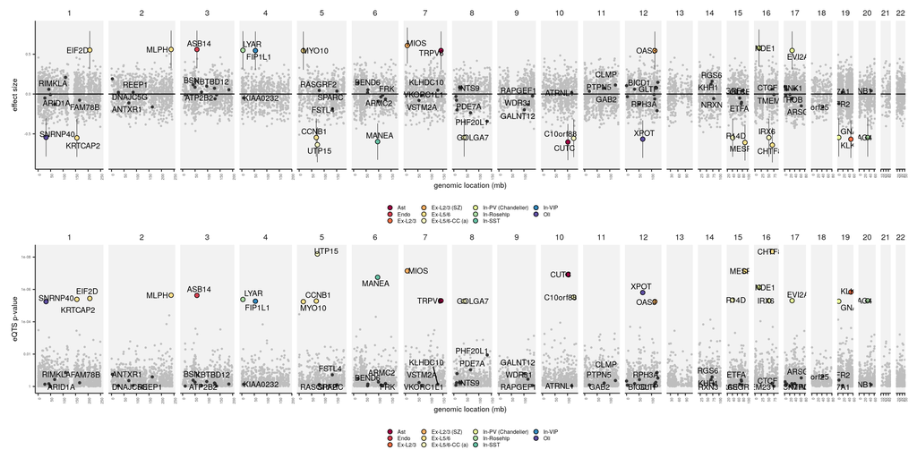

```r
################################################################
.dt = eqts.tab[gwas %in% c("clozuk_scz", "pgc_scz")]

.dt.sig = .dt[order(.dt$p.val), head(.SD,1), by=.(gene)]
.dt.sig = .dt.sig[q.val < fdr.cutoff]

.dt.de = .dt[order(.dt$q.val.de), head(.SD,1), by=.(gene)]
.dt.de = .dt.de[q.val.de < fdr.cutoff]
.dt.de.lab = .dt.de[order(.dt.de$q.val.de), head(.SD,3), by=.(`#chr`)]

.dt.rand = .dt[sample(nrow(.dt)), head(.SD, 1), by = .(gene)] # to show random jitter

p1 = .gg.plot(.dt.rand, aes(x=tss, y=beta)) +
  theme(axis.text = element_text(size=4)) +
  theme(axis.text.x = element_text(angle=90, vjust=1, hjust=1)) +
  theme(legend.position = "bottom") +
  theme(legend.title = element_blank()) +
  xlab("genomic location (mb)") + ylab("effect size") +
  scale_x_continuous(labels=function(x) round(x/1e6)) +
  facet_grid(.~`#chr`, scales="free", space="free") +
  geom_point(color="gray", size=.5, pch=19) +
  geom_hline(yintercept = 0) +
  geom_linerange(aes(ymin=beta-2*se,ymax=beta+2*se), data=.dt.sig, size=.2) +
  geom_point(aes(fill=celltype), data=.dt.sig, size=2, pch=21) +
  ggrepel::geom_text_repel(aes(label=gene), data=.dt.sig, size=3) +
  geom_point(data=.dt.de, size=1, pch=19, color="gray20") +
  ggrepel::geom_text_repel(aes(label=gene), data=.dt.de.lab, size=3) +
  scale_fill_brewer(palette="Spectral")

p2 = .gg.plot(.dt.rand, aes(x=tss, y=-log10(p.val))) +
  theme(axis.text = element_text(size=4)) +
  theme(axis.text.x = element_text(angle=90, vjust=1, hjust=1)) +
  theme(legend.position = "bottom") +
  theme(legend.title = element_blank()) +
  xlab("genomic location (mb)") + ylab("eQTS p-value") +
  scale_x_continuous(labels=function(x) round(x/1e6)) +
  scale_y_continuous(labels=function(x) 10^(-x)) +
  facet_grid(.~`#chr`, scales="free", space="free") +
  geom_point(color="gray", size=.5, pch=19) +
  geom_point(aes(fill=celltype), data=.dt.sig, size=2, pch=21) +
  ggrepel::geom_text_repel(aes(label=gene), data=.dt.sig, size=3) +
  geom_point(data=.dt.de, size=1, pch=19, color="gray20") +
  ggrepel::geom_text_repel(aes(label=gene), data=.dt.de.lab, size=3) +
  scale_fill_brewer(palette="Spectral")

plt = p1 / p2

print(plt)
```

```r
.file = fig.dir %&% "/FigEQTS_SZ.pdf"
.gg.save(.file, plot=plt, width=14, height=7)
cat("[PDF](" %&% .file %&% ")\n")
```

PDF

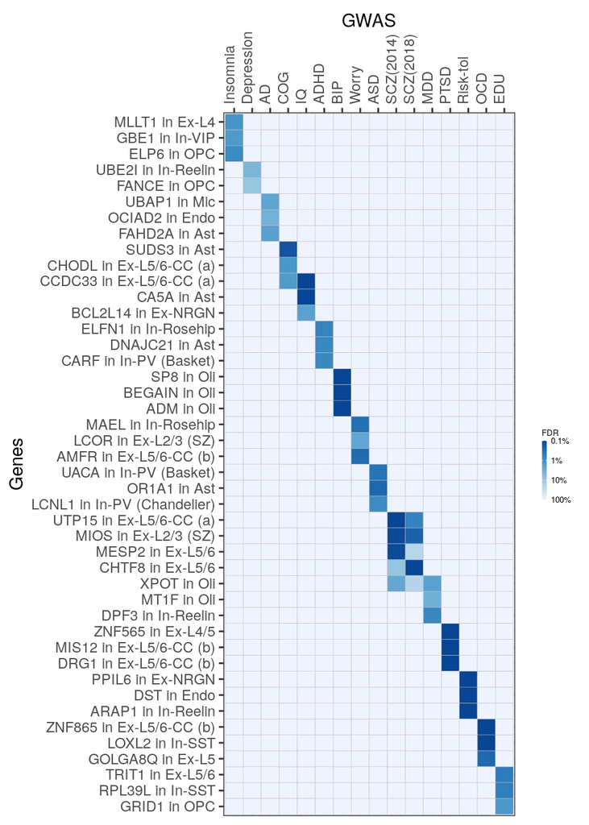

```r
.dt = .eqts[q.val < fdr.cutoff]

.gene.ct = .dt[order(.dt$p.val), head(.SD, 1), by = .(gene, gwas)]
.gene.ct = .gene.ct[, head(.SD, 3), by = .(gwas)]
.gene.ct = .gene.ct[, .(gene, celltype)] %>% distinct() %>% as_tibble

.dt = left_join(.gene.ct, .eqts) %>%
  left_join(trait.names, by = "gwas") %>%
  as.data.table

.dt = .dt[order(.dt$p.val), head(.SD,1), by=.(gwas.name, gene)] %>%
  mutate(row = gwas.name) %>%
  mutate(col = gene %&% " in " %&&% celltype) %>%
  mutate(weight = -log10(p.val)) %>%
  order.pair(ret.tab = TRUE) %>%
  as.data.table()

plt = ggplot(.dt, aes(x=row, y=col)) +
  theme_bw() +
  theme(axis.text.x = element_text(angle=90, vjust=0, hjust=0)) +
  theme(legend.key.width=unit(.2,'lines')) +
  theme(legend.key.height=unit(.5,'lines')) +
  theme(legend.text=element_text(size=5)) +
  theme(legend.title=element_text(size=5)) +
  xlab("GWAS") +
  ylab("Genes") +
  scale_x_discrete(position = "top") +
  geom_tile(aes(fill = -log10(pmax(q.val, 1e-3))), color="gray") +
  scale_fill_distiller("FDR", direction = 1, palette="Blues",
                       labels=function(x) num.round(100*10^(-x)) %&% "%") +
  scale_size_continuous(range=c(0,5), labels=function(x) 10^(-x))

print(plt)
```

```r
.file = fig.dir %&% "/FigEQTS.pdf"
.gg.save(.file, plot=plt, width=5, height=7)
cat("[PDF](" %&% .file %&% ")\n")
```

PDF

clozuk_scz ctg_ad ctg_depressed-a ctg_insomnia ctg_iq ctg_worry pgc_adhd pgc_asd pgc_bip pgc_mdd pgc_ocd pgc_ptsd pgc_scz ssgac_cog ssgac_edu ssgac_risk-tol

```r
plot.eqts.ct <- function(.ct) {

  .dt = .eqts %>%
    filter(celltype == .ct) %>%
    merge(de.pval.tab, by = c("gene", "celltype")) %>%
    merge(trait.names, by = "gwas") %>%
    na.omit

  .dt = .dt %>%
    mutate(row = gwas.name) %>%
    mutate(col = gene) %>%
    mutate(weight = -log10(p.val)) %>%
    order.pair(ret.tab = TRUE) %>%
    as.data.table()

  .dt.mark = .dt[q.val < fdr.cutoff]

  ggplot(.dt, aes(x=row, y=col)) +
    ggtitle(.ct) +
    theme_bw() +
    theme(axis.text.x = element_text(angle=90, vjust=0, hjust=0)) +
    theme(legend.key.width=unit(.2,'lines')) +
    theme(legend.key.height=unit(.5,'lines')) +
    theme(legend.text=element_text(size=5)) +
    theme(legend.title=element_text(size=5)) +
    xlab("GWAS") +
    ylab("Genes") +
    scale_x_discrete(position = "top") +
    geom_point(aes(size=weight,fill=beta), pch=22, stroke=.2) +
    geom_point(data=.dt.mark, pch="*", color="white", size=5) +
    scale_size_continuous("p-value", range=c(0,5), breaks=seq(0,5), labels=function(x) 10^(-x)) +
    scale_fill_distiller("eQTS\neffect", palette="RdBu",direction=-1)

}
```

## methods

### Robust polygenic risk score prediction by spectral decomposition

We estimate polygenic risk score (PRS) using spectral decomposition of the underlying genotype matrix, $X$ (sample by variants), of the cohort. We propose a robust and straightforward PRS method that estimates a vector of multivariate effect size, $\boldsymbol{\theta}$, from a vector of univariate GWAS summary statistics. If we have sufficiently large number of individuals, we can simply estimate $\boldsymbol{\theta} = R^{-1} \mathbf{z}$ by taking an inverse matrix of the LD matrix, namely $R \overset{\Delta}{=} X^{\top}X/n$. In practice, we take the psuedo-inverse of $R$, namely $R^{-1}\approx VD^{-2}V^{\top}$, based on singular value decomposition of the genotype matrix, $X=UDV^{\top}$, and this results in the estimate of multivariate effect size $\boldsymbol{\theta} \approx VD^{-2}V^{\top}\mathbf{z}$. By substituting this result to a linear model, $\mathbf{y} \sim X \boldsymbol{\theta}$, we predict a PRS vector, $\hat{\mathbf{y}} = UD^{-1}V^{\top}\mathbf{z}$. To account for discrepancy of the LD matrix $R$ between our cohort and the actual GWAS cohort, we introduce regularization parameter $\tau$ (ridge regression): $\hat{\mathbf{y}} = U(D + \tau I)^{-1}V^{\top} \mathbf{z}$.

### Hyper-parameter tuning without phenotype labels

A conventional PRS approach tunes hyper-parameters, such as p-value thresholding and LD-clumping, by comparing the predicted PRS vector $\hat{\mathbf{y}}$ against actual observed phenotypes $\mathbf{y}_{\mathsf{obs}}$. Here, we show that the regularization parameter $\tau$ can be optimized without looking at the observed $\mathbf{y}_{\mathsf{obs}}$. Instead of optimizing the prediction accuracy cross-validated against a small cohort of individuals, we focus on improving the robustness of PRS methods across multiple cohorts. The basic idea is that we want a prediction score (and the underlying regression coefficient matrix) is robustly reproducible across multiple cohorts.

Here we use the genotypes of 154 individuals as a primary matrix $X$, while additionally using the 1000G reference panel genotype matrix $\tilde{X}$. Let us define the multivariate regression parameters $\hat{\theta}(\tau) \overset{\Delta}{=} V(D + \tau I)^{-2}V^{\top}\mathbf{z}$ as a function of the hyperparameter $\tau$. We can construct a prediction vector on a new genotype matrix $\tilde{X}$ for each $\tau$ value, namely $\mathbf{y}(\tau)\overset{\Delta}{=} \tilde{X} \hat{\theta}(\tau)$. On the other hand, based on the SVD of the 1000G panel, namely $\tilde{X} = \tilde{U} \tilde{D} \tilde{V}^{\top}$, we can construct another PRS vector $\tilde{\mathbf{y}} = \tilde{U} \tilde{D}^{-1} \tilde{V}^{\top} \mathbf{z}$.

## Reference

Pardiñas, A. F., Holmans, P., Pocklington, A. J., Escott-Price, V., Ripke, S., Carrera, N., … CRESTAR Consortium. (2018). Common schizophrenia alleles are enriched in mutation-intolerant genes and in regions under strong background selection. *Nat. Genet.*

Schizophrenia Working Group of the Psychiatric Genomics Consortium. (2014). Biological insights from 108 schizophrenia-associated genetic loci. *Nature*, *511*(7510), 421–427.

The 1000 Genomes Project Consortium, Lander, E. S., Danecek, P., Genovese, G., Hurles, M. E., Abyzov, A., … Abecasis, G. R. (2015). A global reference for human genetic variation. *Nature*, *526*(7571), 68–74.

Võsa, U., Claringbould, A., Westra, H.-J., Bonder, M. J., Deelen, P., Zeng, B., … Franke, L. (2018). *Unraveling the polygenic architecture of complex traits using blood eQTL meta-analysis*. *bioRxiv*.